# A quantitative gesture analysis of 737 videos and 546 speakers in the TV News Archive

Greg Woodin, Bodo Winter, Marcus Perlman, Teenie Matlock, Jeannette Littlemore

27/11/2018

# 1 Preliminaries

This is the code used for the analysis reported in ‘A quantitative gesture analysis of 737 videos and 546 speakers in the TV News Archive’.

Load packages used, load datasets and give them shorter names for easier coding:

```r
library(tidyverse)    # Data processing
library(lme4)   # Fitting logistic regression models
library(scales)   # Adding line breaks to plots
library(car)    # Identifying collinearity issues
library(gridExtra)    # Arranging plots in a grid

# Data:
(size <- read_csv('tinyhuge_alldata_coded.csv'))    # 'Tiny/huge number' dataset
```

```
## # A tibble: 804 x 31
##       ID URL   Archive_ID Title SpeakerName HasPhrase Phrase Negated Plural
##    <int> <chr> <chr>      <chr> <chr>       <chr>     <chr>  <chr>   <chr>
##  1  4939 http… CSPAN2_20… Toni… iain dunca… yes       huge_… no      no
##  2  9433 http… MSNBC_201… Hard… anita dunn  yes       huge_… no      no
##  3   338 http… CSPAN_201… Wash… claire mcc… yes       tiny_… no      no
##  4  1715 http… FOXNEWS_2… The … steven cen… yes       huge_… no      no
##  5   356 http… CSPAN_201… Key … james jay … yes       tiny_… no      no
##  6   204 http… KQED_2014… PBS … <NA>        yes       tiny_… no      no
##  7  6449 http… CNBC_2014… Squa… jim cramer  yes       huge_… no      no
##  8  5865 http… CSPAN3_20… Poli… thilo kosl… yes       huge_… no      no
##  9   368 http… CSPAN2_20… Toda… john harwo… yes       tiny_… no      no
## 10  9593 http… CNN_20120… CNN … haroon mog… yes       huge_… yes     no
## # ... with 794 more rows, and 22 more variables: SpeakerVisible <chr>,
## #   HandsVisible <chr>, HandsVisibleGenerous <chr>, HandsFree <chr>,
## #   HandsMoving <chr>, NounPlural <chr>, ContextMove <chr>,
## #   Duplicated <chr>, WhichHand <chr>, HandConfig <chr>, PinchType <chr>,
## #   PinkieCurl <chr>, PalmOrientation <chr>, MovementVertical <chr>,
## #   MovementHorizontal <chr>, MovementSagittal <chr>, QuantityType <chr>,
## #   QuantityValue <chr>, VerbatimReferent <chr>, QuantityContrast <chr>,
## #   OfInterest <chr>, Comments <chr>
```

```r
(height <- read_csv('highlow_alldata_coded.csv'))   # 'Low/high number' dataset
```

```
## # A tibble: 869 x 31
##       ID URL   Archive_ID Title SpeakerName HasPhrase Phrase Negated Plural
##    <int> <chr> <chr>      <chr> <chr>       <chr>     <chr>  <chr>   <chr>
##  1   795 http… CSPAN2_20… Book… peter berg… yes       low_n… no      no
##  2   814 http… MSNBC_201… MSNB… morgan bre… yes       low_n… no      yes
##  3   249 http… WBFF_2010… Fox … no          yes       high_… no      no
##  4   720 http… CNN_20110… In t… michio kaku yes       low_n… no      yes
##  5   556 http… CSPAN2_20… U.S.… richard ha… yes       low_n… no      no
##  6   449 http… KPIX_2014… KPIX… kiet do     yes       high_… no      no
##  7   636 http… CSPAN2_20… U.S.… cristina l… yes       low_n… no      yes
##  8   117 http… CSPAN2_20… Toni… ray lahood  yes       high_… no      no
##  9   566 http… CSPAN_201… U.S.… sheila jac… yes       low_n… no      no
## 10   607 http… FOXNEWSW_… Amer… no          yes       low_n… no      no
## # ... with 859 more rows, and 22 more variables: SpeakerVisible <chr>,
## #   HandsVisible <chr>, HandsVisibleGenerous <chr>, HandsFree <chr>,
## #   HandsMoving <chr>, NounPlural <chr>, ContextMove <chr>,
## #   Duplicated <chr>, WhichHand <chr>, HandConfig <chr>, PinchType <chr>,
## #   PinkieCurl <chr>, PalmOrientation <chr>, MovementVertical <chr>,
## #   MovementHorizontal <chr>, MovementSagittal <chr>, QuantityType <chr>,
## #   QuantityValue <chr>, VerbatimReferent <chr>, QuantityContrast <chr>,
## #   OfInterest <chr>, Comments <chr>
```

```r
(valence <- read_csv('DoM_data.csv'))   # 'Standards' dataset (low, high, lower, raise)
```

```
## # A tibble: 1,600 x 38
##    Order    ID Archive_ID Title URL   Snippet Phrase HasPhrase
##    <int> <int> <chr>      <chr> <chr> <chr>   <chr>  <chr>
##  1     1    31 WTMJ_2016… Toda… http… "wacky… low_s… no
##  2     2   782 CSPAN_201… Toda… http… only w… low_s… yes
##  3     3   347 FOXNEWSW_… Spec… http… least … low_s… yes
##  4     4   768 CSPAN_201… C-SP… http… . it i… low_s… yes
##  5     5   711 KNTV_2014… Toda… http… standa… low_s… yes
##  6     6   512 CNN_20121… CNN … http… pretty… low_s… yes
##  7     7   775 CSPAN_201… Wash… http… is pro… low_s… yes
##  8     8   494 CSPAN2_20… Publ… http… off an… low_s… yes
##  9     9   266 MSNBCW_20… The … http… "of th… low_s… yes
## 10    10   276 FOXNEWSW_… Outn… http… traffi… low_s… yes
## # ... with 1,590 more rows, and 30 more variables: SpeakerVisible <chr>,
## #   HandsVisible <chr>, HandsVisibleGenerous <chr>, HandsFree <chr>,
## #   HandsFreeGenerous <chr>, Aspect <chr>, Aspect2 <chr>,
## #   Participle <chr>, Agent <chr>, Animacy <chr>, Negated <chr>,
## #   Contrasted <chr>, Focus <chr>, FocusExamp <chr>, SpeakerName <chr>,
## #   Duplicate <chr>, NonNative <chr>, HandsMoving <chr>, NounPlural <chr>,
## #   ContextMove <chr>, WhichHand <chr>, HandConfig <chr>,
## #   PalmOrientation <chr>, MovementVertical <chr>,
## #   MovementHorizontal <chr>, MovementSagittal <chr>, Duration <chr>,
## #   StrokeDuration <chr>, OfInterest <chr>, Comments <chr>
```

Reduce datasets to only those videos which were analysable from a gestural perspective and find out how many videos remain at each stage of the reduction process:

```r
# Overall:
nrow(size) + nrow(height) + nrow(valence)
```

```
## [1] 3273
```

```r
# HasPhrase == "yes":
size <- filter(size, HasPhrase != "no")
height <- filter(height, HasPhrase != "no")
valence <- filter(valence, HasPhrase != "no")
nrow(size) + nrow(height) + nrow(valence)
```

```
## [1] 2839
```

```r
# SpeakerVisible == "yes":
size <- filter(size, SpeakerVisible != "no")
height <- filter(height, SpeakerVisible != "no")
valence <- filter(valence, SpeakerVisible != "no")
nrow(size) + nrow(height) + nrow(valence)
```

```
## [1] 2033
```

```r
# HandsVisibleGenerous == "one" or "both":
size <- filter(size, HandsVisibleGenerous != "neither")
height <- filter(height, HandsVisibleGenerous != "neither")
valence <- filter(valence, HandsVisibleGenerous != "neither")
nrow(size) + nrow(height) + nrow(valence)
```

```
## [1] 985
```

```r
# HandsFree == "one" or "both":
size <- filter(size, HandsFree != "neither")
height <- filter(height, HandsFree != "neither")
valence <- filter(valence, HandsFree != "neither")
nrow(size) + nrow(height) + nrow(valence)
```

```
## [1] 839
```

```r
# Negated == 'NA' or "no":
size <- filter(size, is.na(Negated) | Negated != "yes")
height <- filter(height, is.na(Negated) | Negated != "yes")
valence <- filter(valence, is.na(Negated) | Negated != "yes")
nrow(size) + nrow(height) + nrow(valence)
```

```
## [1] 816
```

```r
# ContextMove == 'NA' or 'yes':
size <- filter(size, is.na(ContextMove) | ContextMove != "no")
height <- filter(height, is.na(ContextMove) | ContextMove != "no")
valence <- filter(valence, is.na(ContextMove) | ContextMove != "no")
nrow(size) + nrow(height) + nrow(valence)
```

```
## [1] 795
```

```r
# Duplicated == 'NA' or 'no':
size <- filter(size, is.na(Duplicated) | Duplicated != "yes")
height <- filter(height, is.na(Duplicated) | Duplicated != "yes")
valence <- filter(valence, is.na(Duplicate) | Duplicate != "yes")
nrow(size) + nrow(height) + nrow(valence)
```

```
## [1] 737
```

Create a plot showing reduction in size of dataset from 3273 videos to 737 videos (Figure 1):

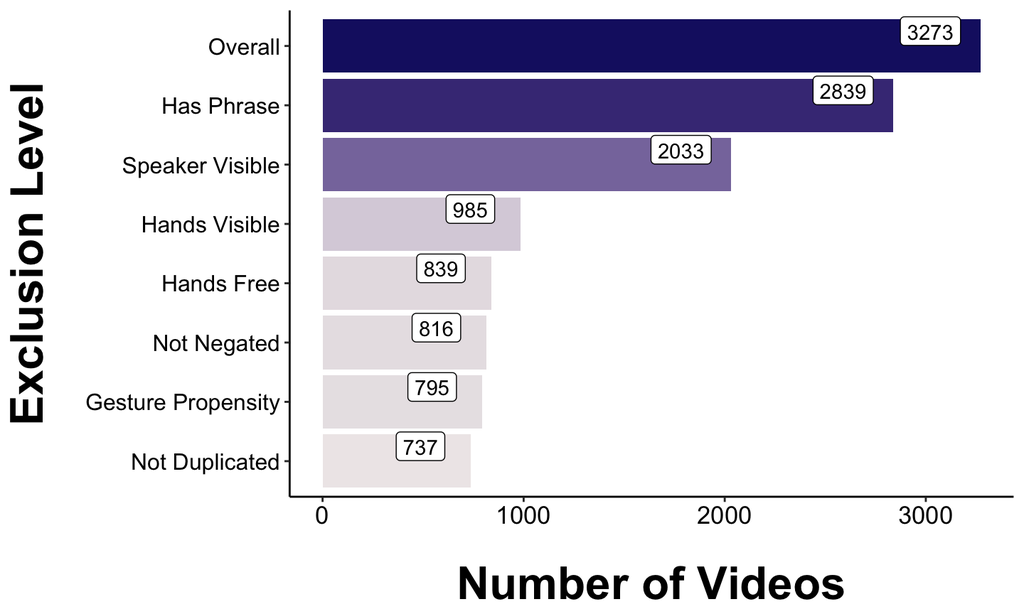

```r
# Create dataframe:
reduc <- data.frame(
  c("Overall", "Has Phrase", "Speaker Visible", "Hands Visible", "Hands Free", "Not Negated", "Gesture Propensity", "Not Duplicated"),
  c(3273, 2839, 2033, 985, 839, 816, 795, 737))

# Preliminary work to make graph:
colnames(reduc) = c("level", "videos")    # Change column names
reduc$level <- factor(reduc$level, levels = c("Not Duplicated", "Gesture Propensity", "Not Negated", "Hands Free", "Hands Visible", "Speaker Visible", "Has Phrase", "Overall"))    # Create factor and order levels
bold.24.text <- element_text(size = 24, face = "bold")    # Create font style for axis titles
black.18.text <- element_text(size = 18, color = "black")    # Create font style for axis labels
black.13.text <- element_text(size = 13, color = "black")    # Create font style for axis labels
bold.21.text <- element_text(size = 19, face = "bold")    # Create font style for legend title

# Make graph:
reduc %>%
  ggplot(aes(x = reduc$level, y = reduc$videos, fill = reduc$videos)) +
  geom_bar(stat = "identity", show.legend = FALSE) +
  geom_label(aes(label = videos), vjust = - 0.02, nudge_y = -250, colour = "black", fill = 'white', alpha = 1, show.legend = FALSE) +
  coord_flip() +
  theme_classic() +
  xlab('Exclusion Level') +
  ylab('Number of Videos') +
  theme(axis.title = bold.24.text, axis.text.y = element_text(size = 12)) +
  theme(axis.text = black.13.text) +
  theme(axis.title.y = element_text(margin = margin(t = 0, r = 20, b = 0, l = 0))) +
  theme(axis.title.x = element_text(margin = margin(t = 20, r = 0, b = 0, l = 0))) +
  scale_fill_gradient(low = "snow2", high = "midnightblue")
```

```r
ggsave('exclusion_plot.pdf', width = 7.5, height = 4.5)
```

Also check how many videos there are in each dataset:

```r
# Tiny/huge numbers:
nrow(size)
```

```
## [1] 195
```

```r
# Low/high numbers:
nrow(height)
```

```
## [1] 165
```

```r
# Standards:
nrow(valence)
```

```
## [1] 377
```

Check how many unique speakers there are in each dataset and overall:

```r
# Tiny/huge numbers:
(size_length <- length(unique(size$SpeakerName)))
```

```
## [1] 166
```

```r
# Low/high numbers:
(height_length <- length(unique(height$SpeakerName)))
```

```
## [1] 123
```

```r
# Standards:
(valence_length <- length(unique(valence$SpeakerName)))
```

```
## [1] 257
```

```r
# Overall:
size_length + height_length + valence_length
```

```
## [1] 546
```

# 2 Main comparisons

We now discuss the main comparisons of the paper, looking at whether the form of a speaker’s gesture matches the metaphorical meaning of the phrase they are using.

## 2.1 Tiny/huge number: hand configuration

We hypothesise that speakers will perform proportionally more closed gestures when saying ‘tiny numbers’ and proportionally more open gestures when saying ‘huge numbers’.

```r
size2 <- filter(size, HandConfig != "object")    # Remove 'object' values
(xtab <- table(size2$Phrase, size2$HandConfig))    # Raw counts
```

```
##
##               closed open
##   huge_number     10   71
##   tiny_number     55   30
```

```r
round(prop.table(xtab, 1), 3) * 100    # Row-wise percentages
```

```
##
##               closed open
##   huge_number   12.3 87.7
##   tiny_number   64.7 35.3
```

It looks like our hypothesis might be accurate. Make a plot showing these results (Figure 2a).

```r
# Preliminary work to make graph:
prop.table <- prop.table(xtab, 1)    # Row-wise percentages
xtab <- as.data.frame(prop.table)   # Turn table into dataframe
as.numeric(xtab$Freq)   # Turn Frequency into numeric variable
```

```
## [1] 0.1234568 0.6470588 0.8765432 0.3529412
```

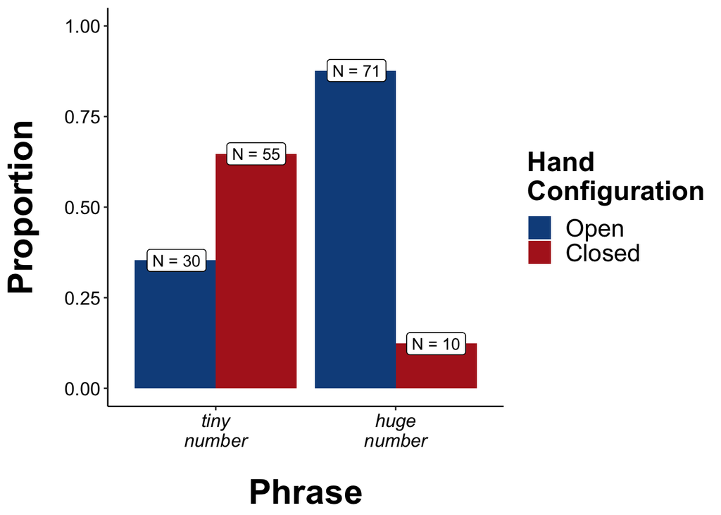

```r
xtab$Var1 <- factor(xtab$Var1, levels = c("tiny_number", "huge_number"))   # Turn x-axis variables into a factor and re-order variables
xtab$Var2 <- factor(xtab$Var2, levels = c('open', 'closed'))    # Turn legend variables into a factor

# Create function to add line breaks to x-axis labels:
addline_format <- function(x,...){
    gsub('\\s','\n',x)}

# Make graph:
xtab %>%
  ggplot(aes(x = xtab$Var1, y = Freq, fill = factor(Var2))) +
  geom_bar(stat = "identity", position = "dodge") +
  ylim(0, 1) +
  theme_classic() +
  xlab('Phrase') +
  ylab('Proportion') +
  theme(axis.title = bold.24.text, legend.text = element_text(size = 17), legend.title = bold.21.text) +
  theme(axis.text = black.13.text, axis.text.x = element_text(face = "italic")) +
  theme(axis.title.y = element_text(margin = margin(t = 0, r = 20, b = 0, l = 0))) +
  theme(axis.title.x = element_text(margin = margin(t = 20, r = 0, b = 0, l = 0))) +
  scale_fill_manual(values = c('dodgerblue4', 'firebrick'), breaks = c("open","closed"), name = addline_format("Hand Configuration"), labels = c("Open", "Closed")) +
  scale_x_discrete(labels = addline_format(c('tiny number', 'huge number'))) +
  geom_label(aes(x = 1.225, y = 0.647, label = "N = 55"), fill = "white", size = 4) +
  geom_label(aes(x = 0.7825, y = 0.353, label = "N = 30"), fill = "white", size = 4) +
  geom_label(aes(x = 2.225, y = 0.123, label = "N = 10"), fill = "white", size = 4) +
  geom_label(aes(x = 1.7825, y = 0.877, label = "N = 71"), fill = "white", size = 4)
```

```r
ggsave('handconfiguration_size.pdf', width = 7, height = 4.5)
```

Check this with logistic regression:

```r
# Preliminaries:
size2$Phrase <- factor(size2$Phrase, levels = c("tiny_number", "huge_number"))    # Turn Phrase into a factor and re-order levels
size2$HandConfig <- as.factor(size2$HandConfig)   # Turn HandConfig into a factor

# Input, summarise and plot logistic regression model:
summary(LR <- glm(HandConfig ~ Phrase, data = size2, family = "binomial"))
```

```
##
## Call:
## glm(formula = HandConfig ~ Phrase, family = "binomial", data = size2)
##
## Deviance Residuals:
##     Min       1Q   Median       3Q      Max
## -2.0454  -0.9331   0.5134   0.5134   1.4432
##
## Coefficients:
##                   Estimate Std. Error z value Pr(>|z|)
## (Intercept)        -0.6061     0.2270  -2.671  0.00757 **
## Phrasehuge_number   2.5662     0.4069   6.306 2.86e-10 ***
## ---
## Signif. codes:  0 '***' 0.001 '**' 0.01 '*' 0.05 '.' 0.1 ' ' 1
##
## (Dispersion parameter for binomial family taken to be 1)
##
##     Null deviance: 222.26  on 165  degrees of freedom
## Residual deviance: 170.92  on 164  degrees of freedom
## AIC: 174.92
##
## Number of Fisher Scoring iterations: 4
```

This logistic regression model shows that, in line with our hypothesis, speakers were more likely to produce open gestures when saying ‘huge number’, and to produce closed gestures when saying ‘tiny number’. To account for the independence assumption of the model being violated, let’s run a for loop that simulates this test again 1000 times with random samples containing only unique speakers.

```r
set.seed(13)    # Make example reproducible
nsim <- 1000    # Create object containing information about number of simulations
loop_p <- numeric(length = nsim)    # Create numeric object to store p-values from simulations

for (i in 1:nsim) {
  size_loop <- sample_n(size2, size = nrow(size2))
  size_reduc <- filter(size_loop, !duplicated(SpeakerName))
  summary(LR <- glm(HandConfig ~ Phrase, data = size_reduc, family = "binomial"))
  loop_p[i] <- summary(LR)$coefficients[2,4]}

sum(loop_p < 0.05)    # Find number of p-values less than 0.05
```

```
## [1] 1000
```

All 1000 samples returned a statistically reliable result. Let’s see what specific types of closed gestures speakers used.

```r
# Pinch type:
(xtab <- table(size2$Phrase, size2$PinchType))
```

```
##
##               bunch bunch/pinch fist lobster_claw ok ok/pinch pinch point
##   tiny_number     7           1    2           14  5        1    23     2
##   huge_number     0           0    4            1  2        0     2     1
```

```r
round(prop.table(xtab, 1), 3) * 100
```

```
##
##               bunch bunch/pinch fist lobster_claw   ok ok/pinch pinch
##   tiny_number  12.7         1.8  3.6         25.5  9.1      1.8  41.8
##   huge_number   0.0         0.0 40.0         10.0 20.0      0.0  20.0
##
##               point
##   tiny_number   3.6
##   huge_number  10.0
```

```r
# Pinkie curl:
(xtab <- table(size2$Phrase, size2$PinkieCurl))
```

```
##
##               curled extended extended/curled
##   tiny_number     41       12               2
##   huge_number      8        2               0
```

```r
round(prop.table(xtab, 1), 3) * 100
```

```
##
##               curled extended extended/curled
##   tiny_number   74.5     21.8             3.6
##   huge_number   80.0     20.0             0.0
```

Let’s now compare the proportion of gestures that involve the index finger and thumb as standing out from the rest (lobster claw, ok, ok/pinch, pinch) to those that don’t (bunch, bunch/pinch) for the phrase ‘tiny numbers’.

```r
size3 <- filter(size2, Phrase == 'tiny_number')   # Restrict dataset to 'tiny numbers'
size3 <- mutate(size3, IndexExtend = ifelse(PinchType %in% c('lobster_claw', 'ok', 'ok/pinch', 'pinch'), 'yes', 'no'))    # Create new column

(xtab <- table(size3$IndexExtend))    # Raw counts
```

```
##
##  no yes
##  42  43
```

```r
round(prop.table(xtab), 3) * 100    # Percentages
```

```
##
##   no  yes
## 49.4 50.6
```

```r
binom.test(xtab)    # Binomial test
```

```
##
##  Exact binomial test
##
## data:  xtab
## number of successes = 42, number of trials = 85, p-value = 1
## alternative hypothesis: true probability of success is not equal to 0.5
## 95 percent confidence interval:
##  0.3838556 0.6048014
## sample estimates:
## probability of success
##              0.4941176
```

Hardly any difference at all.

## 2.2 Low/high numbers: vertical movement

Let’s now look at vertical movement for each phrase. We hypothesise that speakers will produce proportionally more downwards-moving gestures when saying ‘low number’ and proportionally more upwards-moving gestures when saying ‘high number’.

```r
(xtab <- table(height$Phrase, height$MovementVertical))    # Raw counts
```

```
##
##               down up
##   high_number   29 13
##   low_number    38  3
```

```r
round(prop.table(xtab, 1), 3) * 100    # Row-wise percentages
```

```
##
##               down   up
##   high_number 69.0 31.0
##   low_number  92.7  7.3
```

Create plot to show these figures (Figure 2b):

```r
# Preliminary work to make graph:
prop.table <- prop.table(xtab, 1)    # Row-wise percentages
xtab <- as.data.frame(prop.table)   # Turn table into dataframe
as.numeric(xtab$Freq)   # Turn Frequency into numeric variable
```

```
## [1] 0.69047619 0.92682927 0.30952381 0.07317073
```

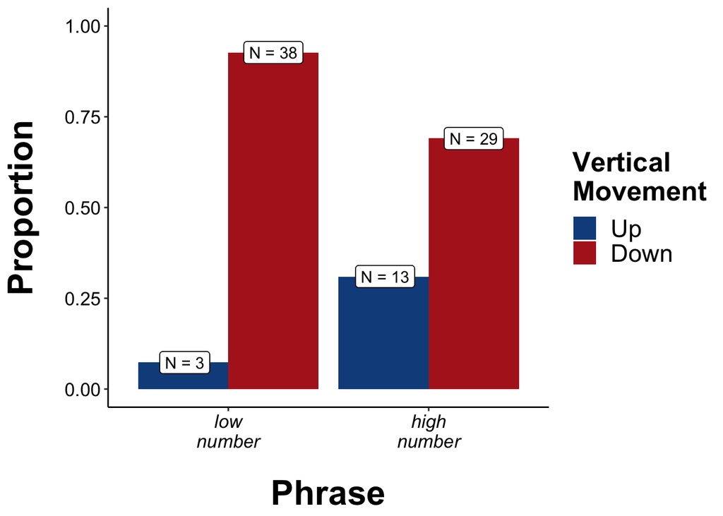

```r
xtab$Var1 <- factor(xtab$Var1, levels = c("low_number", "high_number"))   # Turn x-axis variables into a factor and re-order variables
xtab$Var2 <- factor(xtab$Var2, levels = c('up', 'down'))    # Turn legend variables into a factor

# Make graph:
xtab %>%
  ggplot(aes(x = xtab$Var1, y = Freq, fill = factor(Var2))) +
  geom_bar(stat = "identity", position = "dodge") +
  ylim(0, 1) +
  theme_classic() +
  xlab('Phrase') +
  ylab('Proportion') +
  theme(axis.title = bold.24.text, legend.text = element_text(size = 17), legend.title = bold.21.text) +
  theme(axis.text = black.13.text, axis.text.x = element_text(face = "italic")) +
  theme(axis.title.y = element_text(margin = margin(t = 0, r = 20, b = 0, l = 0))) +
  theme(axis.title.x = element_text(margin = margin(t = 20, r = 0, b = 0, l = 0))) +
  scale_fill_manual(values = c('dodgerblue4', 'firebrick'), breaks = c("up","down"), name = addline_format("Vertical Movement"), labels = c("Up", "Down")) +
  scale_x_discrete(labels = addline_format(c('low number', 'high number'))) +
  geom_label(aes(x = 1.225, y = 0.927, label = "N = 38"), fill = "white", size = 4) +
  geom_label(aes(x = 0.7825, y = 0.073, label = "N = 3"), fill = "white", size = 4) +
  geom_label(aes(x = 2.225, y = 0.69, label = "N = 29"), fill = "white", size = 4) +
  geom_label(aes(x = 1.7825, y = 0.31, label = "N = 13"), fill = "white", size = 4)
```

```r
ggsave('verticalmovement_height.pdf', width = 6.5, height = 4.5)
```

These descriptive statistics suggest that, although downwards-moving gestures were more prevalent overall, downwards-moving gestures were in fact preferred for the phrase ‘low number’ compared to ‘high number’. Let’s check this with logistic regression.

```r
# Preliminaries:
height$Phrase <- factor(height$Phrase, levels = c("low_number", "high_number"))    # Turn Phrase into a factor and re-order levels
height$MovementVertical <- as.factor(height$MovementVertical)   # Turn MovementVertical into a factor

# Input, summarise and plot logistic regression model:
summary(LR <- glm(MovementVertical ~ Phrase, data = height, family = "binomial"))
```

```
##
## Call:
## glm(formula = MovementVertical ~ Phrase, family = "binomial",
##     data = height)
##
## Deviance Residuals:
##     Min       1Q   Median       3Q      Max
## -0.8607  -0.8607  -0.3898  -0.3898   2.2869
##
## Coefficients:
##                   Estimate Std. Error z value Pr(>|z|)
## (Intercept)        -2.5390     0.5997  -4.234  2.3e-05 ***
## Phrasehigh_number   1.7366     0.6863   2.530   0.0114 *
## ---
## Signif. codes:  0 '***' 0.001 '**' 0.01 '*' 0.05 '.' 0.1 ' ' 1
##
## (Dispersion parameter for binomial family taken to be 1)
##
##     Null deviance: 81.376  on 82  degrees of freedom
## Residual deviance: 73.437  on 81  degrees of freedom
##   (82 observations deleted due to missingness)
## AIC: 77.437
##
## Number of Fisher Scoring iterations: 5
```

These results confirm our above interpretation of the descriptive statistics. Let’s now sample the dataset 1000 times with only unique speakers and perform this test again.

```r
set.seed(13)    # Make example reproducible
nsim <- 1000    # Create object containing information about number of simulations
loop_p <- numeric(length = nsim)    # Create numeric object to store p-values from simulations

for (i in 1:nsim) {
  height_loop <- sample_n(height, size = nrow(height))
  height_reduc <- filter(height_loop, !duplicated(SpeakerName))
  summary(LR <- glm(MovementVertical ~ Phrase, data = height_reduc, family = "binomial"))
  loop_p[i] <- summary(LR)$coefficients[2,4]}

sum(loop_p < 0.05)    # Find number of p-values less than 0.05
```

```
## [1] 868
```

868 samples returned a statistically reliable result, which suggests that although repeated speakers may have contributed to the effect we observed overall, this effect is still fairly robust. Perhaps this effect is less robust than the ‘tiny’-closed and ‘huge’-open hand gestures we saw because the adjectives ‘low’ and ‘high’ do not themselves encode vertical movement.

## 2.3 Low/high standards: vertical movement

Let’s now look at vertical movement for the phrases ‘low/high standards’. We hypothesise that speakers will perform proportionally more downwards-moving gestures when saying ‘low standards’ and proportionally more upwards-moving gestures when saying ‘high standards’.

```r
# Restrict dataset to only 'low standards' and 'high standards':
valence2 <- filter(valence, Phrase %in% c('low_standards', 'high_standards'))

# Remove values separated by forward slashes (e.g., 'up/down'):
valence2 <- filter(valence2, MovementVertical %in% c('up', 'down'))

# Descriptive stats:
(xtab <- table(valence2$Phrase, valence2$MovementVertical))    # Raw counts
```

```
##
##                  down up
##   high_standards   25 17
##   low_standards    53  3
```

```r
round(prop.table(xtab, 1), 3) * 100    # Row-wise percentages
```

```
##
##                  down   up
##   high_standards 59.5 40.5
##   low_standards  94.6  5.4
```

Create plot to show these figures (Figure 2c).

```r
# Preliminary work to make graph:
prop.table <- prop.table(xtab, 1)    # Row-wise percentages
xtab <- as.data.frame(prop.table)   # Turn table into dataframe
as.numeric(xtab$Freq)   # Turn Frequency into numeric variable
```

```
## [1] 0.59523810 0.94642857 0.40476190 0.05357143
```

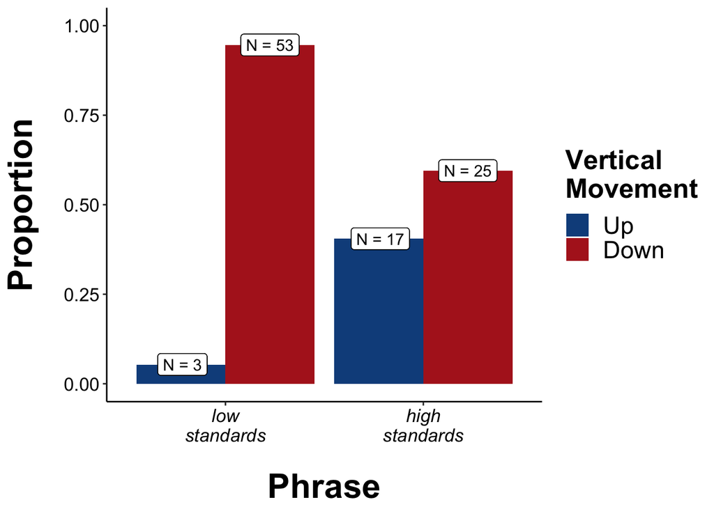

```r
xtab$Var1 <- factor(xtab$Var1, levels = c("low_standards", "high_standards"))   # Turn x-axis variables into a factor and re-order variables
xtab$Var2 <- factor(xtab$Var2, levels = c('up', 'down'))    # Turn legend variables into a factor

# Make graph:
xtab %>%
  ggplot(aes(x = xtab$Var1, y = Freq, fill = factor(Var2))) +
  geom_bar(stat = "identity", position = "dodge") +
  ylim(0, 1) +
  theme_classic() +
  xlab('Phrase') +
  ylab('Proportion') +
  theme(axis.title = bold.24.text, legend.text = element_text(size = 17), legend.title = bold.21.text) +
  theme(axis.text = black.13.text, axis.text.x = element_text(face = "italic")) +
  theme(axis.title.y = element_text(margin = margin(t = 0, r = 20, b = 0, l = 0))) +
  theme(axis.title.x = element_text(margin = margin(t = 20, r = 0, b = 0, l = 0))) +
  scale_fill_manual(values = c('dodgerblue4', 'firebrick'), breaks = c("up","down"), name = addline_format("Vertical Movement"), labels = c("Up", "Down")) +
  scale_x_discrete(labels = addline_format(c('low standards', 'high standards'))) +
  geom_label(aes(x = 1.225, y = 0.946, label = "N = 53"), fill = "white", size = 4) +
  geom_label(aes(x = 0.7825, y = 0.054, label = "N = 3"), fill = "white", size = 4) +
  geom_label(aes(x = 2.225, y = 0.595, label = "N = 25"), fill = "white", size = 4) +
  geom_label(aes(x = 1.7825, y = 0.405, label = "N = 17"), fill = "white", size = 4)
```

```r
ggsave('verticalmovement_adjstandards.pdf', width = 6.5, height = 4.5)
```

As with the ‘low/high number’ phrases, there were more downwards-moving gestures overall, but there were comparatively more upwards-moving gestures for the phrase ‘high standards’ compared to ‘low standards’. Let’s check this with logistic regression.

```r
# Preliminaries:
valence2$Phrase <- factor(valence2$Phrase, levels = c("low_standards", "high_standards"))    # Turn Phrase into a factor and re-order levels
valence2$MovementVertical <- as.factor(valence2$MovementVertical)   # Turn MovementVertical into a factor

# Input, summarise and plot logistic regression model:
summary(LR <- glm(MovementVertical ~ Phrase, data = valence2, family = "binomial"))
```

```
##
## Call:
## glm(formula = MovementVertical ~ Phrase, family = "binomial",
##     data = valence2)
##
## Deviance Residuals:
##     Min       1Q   Median       3Q      Max
## -1.0186  -0.8469  -0.3318  -0.3318   2.4194
##
## Coefficients:
##                      Estimate Std. Error z value Pr(>|z|)
## (Intercept)           -2.8717     0.5934  -4.839 1.31e-06 ***
## Phrasehigh_standards   2.4860     0.6716   3.702 0.000214 ***
## ---
## Signif. codes:  0 '***' 0.001 '**' 0.01 '*' 0.05 '.' 0.1 ' ' 1
##
## (Dispersion parameter for binomial family taken to be 1)
##
##     Null deviance: 99.178  on 97  degrees of freedom
## Residual deviance: 80.088  on 96  degrees of freedom
## AIC: 84.088
##
## Number of Fisher Scoring iterations: 5
```

Check this significant result with a for loop:

```r
set.seed(13)    # Make example reproducible
nsim <- 1000    # Create object containing information about number of simulations
loop_p <- numeric(length = nsim)    # Create numeric object to store p-values from simulations

for (i in 1:nsim) {
  valence_loop <- sample_n(valence2, size = nrow(valence2))
  valence_reduc <- filter(valence_loop, !duplicated(SpeakerName))
  summary(LR <- glm(MovementVertical ~ Phrase, data = valence_reduc, family = "binomial"))
  loop_p[i] <- summary(LR)$coefficients[2,4]}

sum(loop_p < 0.05)    # Find number of p-values less than 0.05
```

```
## [1] 1000
```

All 1000 samples returned a significant result.

## 2.4 Lower/raise the standard: vertical movement

Let’s now look at vertical movement for the phrases ‘lower the standard’ and ‘raise the standard’. We hypothesise that speakers will perform proportionally more downwards-moving gestures when saying ‘lower the standard’ and proportionally more upwards-moving gestures when saying ‘raise the standard’.

```r
# Restrict dataset to only 'lower the standard' and 'raise the standard':
valence3 <- filter(valence, Phrase %in% c('lower_the_standards', 'raise_the_standards'))

# Remove values separated by forward slashes (e.g., 'up/down'):
valence3 <- filter(valence3, MovementVertical %in% c('up', 'down'))

# Descriptive stats:
(xtab <- table(valence3$Phrase, valence3$MovementVertical))    # Raw counts
```

```
##
##                       down up
##   lower_the_standards   85  2
##   raise_the_standards   16 48
```

```r
round(prop.table(xtab, 1), 3) * 100    # Row-wise percentages
```

```
##
##                       down   up
##   lower_the_standards 97.7  2.3
##   raise_the_standards 25.0 75.0
```

Create plot to show these stats (Figure 2d).

```r
# Preliminary work to make graph:
prop.table <- prop.table(xtab, 1)    # Row-wise percentages
xtab <- as.data.frame(prop.table)   # Turn table into dataframe
as.numeric(xtab$Freq)   # Turn Frequency into numeric variable
```

```
## [1] 0.97701149 0.25000000 0.02298851 0.75000000
```

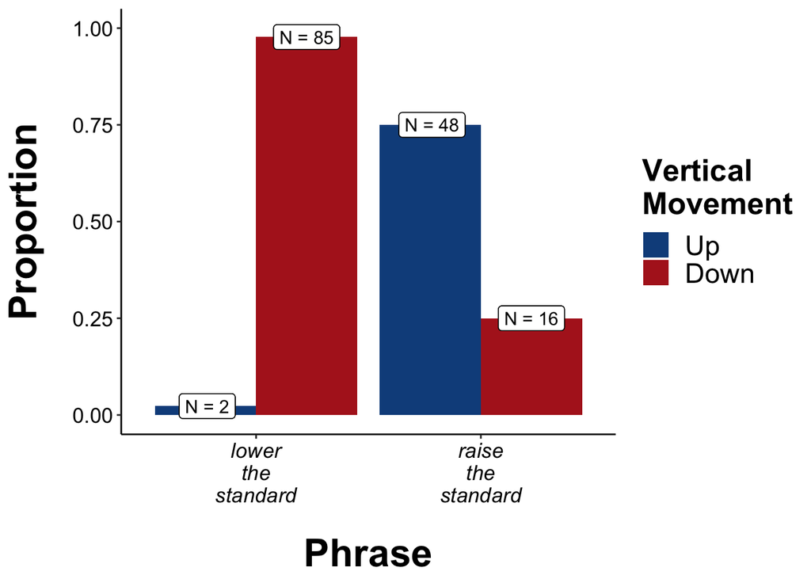

```r
xtab$Var1 <- factor(xtab$Var1, levels = c("lower_the_standards", "raise_the_standards"))   # Turn x-axis variables into a factor and re-order variables
xtab$Var2 <- factor(xtab$Var2, levels = c('up', 'down'))    # Turn legend variables into a factor

# Make graph:
xtab %>%
  ggplot(aes(x = xtab$Var1, y = Freq, fill = factor(Var2))) +
  geom_bar(stat = "identity", position = "dodge") +
  ylim(0, 1) +
  theme_classic() +
  xlab('Phrase') +
  ylab('Proportion') +
  theme(axis.title = bold.24.text, legend.text = element_text(size = 17), legend.title = bold.21.text) +
  theme(axis.text = black.13.text, axis.text.x = element_text(face = "italic")) +
  theme(axis.title.y = element_text(margin = margin(t = 0, r = 20, b = 0, l = 0))) +
  theme(axis.title.x = element_text(margin = margin(t = 20, r = 0, b = 0, l = 0))) +
  scale_fill_manual(values = c('dodgerblue4', 'firebrick'), breaks = c("up","down"), name = addline_format("Vertical Movement"), labels = c("Up", "Down")) +
  scale_x_discrete(labels = addline_format(c('lower the standard', 'raise the standard'))) +
  geom_label(aes(x = 1.225, y = 0.977, label = "N = 85"), fill = "white", size = 4) +
  geom_label(aes(x = 0.7825, y = 0.023, label = "N = 2"), fill = "white", size = 4) +
  geom_label(aes(x = 2.225, y = 0.25, label = "N = 16"), fill = "white", size = 4) +
  geom_label(aes(x = 1.7825, y = 0.75, label = "N = 48"), fill = "white", size = 4)
```

```r
ggsave("verticalmovement_verbstandards.pdf", width = 6.5, height = 4.5)
```

Clearly, speakers were more likely to gesture downwards when using the phrase ‘lower the standard’, and upwards when using the phrase ‘raise the standard’. Let’s check this with a logistic regression model.

```r
# Preliminaries:
valence3$Phrase <- factor(valence3$Phrase, levels = c("lower_the_standards", "raise_the_standards"))    # Turn Phrase into a factor and re-order levels
valence3$MovementVertical <- as.factor(valence3$MovementVertical)   # Turn MovementVertical into a factor

# Input, summarise and plot logistic regression model:
summary(LR <- glm(MovementVertical ~ Phrase, data = valence3, family = "binomial"))
```

```
##
## Call:
## glm(formula = MovementVertical ~ Phrase, family = "binomial",
##     data = valence3)
##
## Deviance Residuals:
##     Min       1Q   Median       3Q      Max
## -1.6651  -0.2157  -0.2157   0.7585   2.7469
##
## Coefficients:
##                           Estimate Std. Error z value Pr(>|z|)
## (Intercept)                -3.7495     0.7154  -5.241 1.59e-07 ***
## Phraseraise_the_standards   4.8481     0.7714   6.285 3.28e-10 ***
## ---
## Signif. codes:  0 '***' 0.001 '**' 0.01 '*' 0.05 '.' 0.1 ' ' 1
##
## (Dispersion parameter for binomial family taken to be 1)
##
##     Null deviance: 191.762  on 150  degrees of freedom
## Residual deviance:  91.024  on 149  degrees of freedom
## AIC: 95.024
##
## Number of Fisher Scoring iterations: 6
```

Unsurprisingly, this result was statistically significant. Let’s now sample the dataset 1000 times with only unique speakers and perform this test again.

```r
set.seed(13)    # Make example reproducible
nsim <- 1000    # Create object containing information about number of simulations
loop_p <- numeric(length = nsim)    # Create numeric object to store p-values from simulations

for (i in 1:nsim) {
  valence_loop <- sample_n(valence3, size = nrow(valence3))
  valence_reduc <- filter(valence_loop, !duplicated(SpeakerName))
  summary(LR <- glm(MovementVertical ~ Phrase, data = valence_reduc, family = "binomial"))
  loop_p[i] <- summary(LR)$coefficients[2,4]}

sum(loop_p < 0.05)    # Find number of p-values less than 0.05
```

```
## [1] 1000
```

All 1000 samples returned a significant result.

# 3 Other comparisons

We now look at whether speakers express a different metaphor in their gestures than they express in speech.

## 3.1 Tiny/huge number: vertical movement

We hypothesise that speakers will be more likely to gesture downwards when saying ‘tiny number’, and upwards when saying ‘huge number’.

```r
(xtab <- table(size$Phrase, size$MovementVertical))    # Raw counts
```

```
##
##               down up
##   huge_number   35  3
##   tiny_number   49 11
```

```r
round(prop.table(xtab, 1), 3) * 100    # Row-wise percentages
```

```
##
##               down   up
##   huge_number 92.1  7.9
##   tiny_number 81.7 18.3
```

These descriptive statistics suggest that the opposite is true: speakers actually produced proportionally more downwards-moving gestures when saying ‘huge number’, and proportionally more upwards-moving gestures when saying ‘tiny number’. On a side note, most gestures overall were downwards-moving, perhaps due to the presence of beat gestures in the dataset, which may often contain a downwards-moving component

Let’s check this with a logistic regression model:

```r
# Preliminaries:
size$Phrase <- factor(size$Phrase, levels = c("tiny_number", "huge_number"))    # Turn Phrase into a factor and re-order levels
size$MovementVertical <- as.factor(size$MovementVertical)   # Turn MovementVertical into a factor

# Input, summarise and plot logistic regression model:
summary(LR <- glm(MovementVertical ~ Phrase, data = size, family = "binomial"))
```

```
##
## Call:
## glm(formula = MovementVertical ~ Phrase, family = "binomial",
##     data = size)
##
## Deviance Residuals:
##     Min       1Q   Median       3Q      Max
## -0.6364  -0.6364  -0.5210  -0.4056   2.2534
##
## Coefficients:
##                   Estimate Std. Error z value Pr(>|z|)
## (Intercept)        -1.4939     0.3336  -4.478 7.55e-06 ***
## Phrasehuge_number  -0.9628     0.6879  -1.400    0.162
## ---
## Signif. codes:  0 '***' 0.001 '**' 0.01 '*' 0.05 '.' 0.1 ' ' 1
##
## (Dispersion parameter for binomial family taken to be 1)
##
##     Null deviance: 80.383  on 97  degrees of freedom
## Residual deviance: 78.160  on 96  degrees of freedom
##   (97 observations deleted due to missingness)
## AIC: 82.16
##
## Number of Fisher Scoring iterations: 5
```

This logistic regression model suggests that there is no statistically reliable relationship between phrase and vertical movement in this instance.

## 3.2 Low/high number: hand configuration

We predict that speakers were be more likely to gesture with a closed hand configuration when saying ‘low number’, and with an open hand configuration when saying ‘high number’.

```r
height2 <- filter(height, HandConfig %in% c("closed", "open"))    # Remove 'object' and 'object/open' values
(xtab <- table(height2$Phrase, height2$HandConfig))    # Raw counts
```

```
##
##               closed open
##   low_number      12   45
##   high_number     12   55
```

```r
round(prop.table(xtab, 1), 3) * 100    # Row-wise percentages
```

```
##
##               closed open
##   low_number    21.1 78.9
##   high_number   17.9 82.1
```

These are only small differences, but there is a slight trend in the direction of our hypothesis. Let’s check this with logistic regression:

```r
# Preliminaries:
height2$Phrase <- factor(height2$Phrase, levels = c("low_number", "high_number"))    # Turn Phrase into a factor and re-order levels
height2$HandConfig <- as.factor(height2$HandConfig)   # Turn MovementVertical into a factor

# Input, summarise and plot logistic regression model:
summary(LR <- glm(HandConfig ~ Phrase, data = height2, family = "binomial"))
```

```
##
## Call:
## glm(formula = HandConfig ~ Phrase, family = "binomial", data = height2)
##
## Deviance Residuals:
##     Min       1Q   Median       3Q      Max
## -1.8546   0.6283   0.6283   0.6876   0.6876
##
## Coefficients:
##                   Estimate Std. Error z value Pr(>|z|)
## (Intercept)         1.3218     0.3249   4.068 4.74e-05 ***
## Phrasehigh_number   0.2007     0.4551   0.441    0.659
## ---
## Signif. codes:  0 '***' 0.001 '**' 0.01 '*' 0.05 '.' 0.1 ' ' 1
##
## (Dispersion parameter for binomial family taken to be 1)
##
##     Null deviance: 121.85  on 123  degrees of freedom
## Residual deviance: 121.65  on 122  degrees of freedom
## AIC: 125.65
##
## Number of Fisher Scoring iterations: 4
```

Unsurprisingly due to the small differences, this test reveals no statistically reliable effect.

## 3.3 Low/high standard: hand configuration

We predict that speakers will be more likely to gesture with a closed hand configuration when saying ‘low standard’, and with an open hand configuration when saying ‘high standard’:

```r
valence2 <- filter(valence2, HandConfig %in% c('open', 'closed'))   # Remove values separated by forward slashes (e.g., 'open/closed')
(xtab <- table(valence2$Phrase, valence2$HandConfig))    # Raw counts
```

```
##
##                  closed open
##   low_standards      11   37
##   high_standards      9   18
```

```r
round(prop.table(xtab, 1), 3) * 100    # Row-wise percentages
```

```
##
##                  closed open
##   low_standards    22.9 77.1
##   high_standards   33.3 66.7
```

There’s actually a trend in the opposite direction of our hypothesis here. Let’s check this with logistic regression.

```r
# Preliminaries:
valence2$Phrase <- factor(valence2$Phrase, levels = c("low_standards", "high_standards"))    # Turn Phrase into a factor and re-order levels
valence2$HandConfig <- as.factor(valence2$HandConfig)   # Turn HandConfig into a factor

# Input, summarise and plot logistic regression model:
summary(LR <- glm(HandConfig ~ Phrase, data = valence2, family = "binomial"))
```

```
##
## Call:
## glm(formula = HandConfig ~ Phrase, family = "binomial", data = valence2)
##
## Deviance Residuals:
##     Min       1Q   Median       3Q      Max
## -1.7166  -1.4823   0.7215   0.7215   0.9005
##
## Coefficients:
##                      Estimate Std. Error z value Pr(>|z|)
## (Intercept)            1.2130     0.3434   3.532 0.000412 ***
## Phrasehigh_standards  -0.5199     0.5335  -0.974 0.329810
## ---
## Signif. codes:  0 '***' 0.001 '**' 0.01 '*' 0.05 '.' 0.1 ' ' 1
##
## (Dispersion parameter for binomial family taken to be 1)
##
##     Null deviance: 86.987  on 74  degrees of freedom
## Residual deviance: 86.045  on 73  degrees of freedom
## AIC: 90.045
##
## Number of Fisher Scoring iterations: 4
```

This model shows no significant effect of phrase on hand configuration.

## 3.4 Lower/raise the standard: hand configuration

We predict that speakers will be more likely to gesture with a closed hand configuration when saying ‘low standard’, and with an open hand configuration when saying ‘high standard’:

```r
valence3 <- filter(valence3, HandConfig %in% c('open', 'closed'))   # Remove values separated by forward slashes (e.g., 'open/closed')
(xtab <- table(valence3$Phrase, valence3$HandConfig))    # Raw counts
```

```
##
##                       closed open
##   lower_the_standards     12   56
##   raise_the_standards      6   44
```

```r
round(prop.table(xtab, 1), 3) * 100    # Row-wise percentages
```

```
##
##                       closed open
##   lower_the_standards   17.6 82.4
##   raise_the_standards   12.0 88.0
```

These are small differences, but it looks like there may be evidence in favour of our hypothesis. Let’s check this with logistic regression.

```r
# Preliminaries:
valence3$Phrase <- factor(valence3$Phrase, levels = c("lower_the_standards", "raise_the_standards"))    # Turn Phrase into a factor and re-order levels
valence3$HandConfig <- as.factor(valence3$HandConfig)   # Turn HandConfig into a factor

# Input, summarise and plot logistic regression model:
summary(LR <- glm(HandConfig ~ Phrase, data = valence3, family = "binomial"))
```

```
##
## Call:
## glm(formula = HandConfig ~ Phrase, family = "binomial", data = valence3)
##
## Deviance Residuals:
##     Min       1Q   Median       3Q      Max
## -2.0593   0.5056   0.5056   0.6231   0.6231
##
## Coefficients:
##                           Estimate Std. Error z value Pr(>|z|)
## (Intercept)                 1.5404     0.3181   4.843 1.28e-06 ***
## Phraseraise_the_standards   0.4520     0.5391   0.838    0.402
## ---
## Signif. codes:  0 '***' 0.001 '**' 0.01 '*' 0.05 '.' 0.1 ' ' 1
##
## (Dispersion parameter for binomial family taken to be 1)
##
##     Null deviance: 100.79  on 117  degrees of freedom
## Residual deviance: 100.07  on 116  degrees of freedom
## AIC: 104.07
##
## Number of Fisher Scoring iterations: 4
```

This model shows no significant effect of phrase on hand configuration.

# 4 Gesture co-occurrence

Let’s look at gesture co-occurrence across all three datasets. Join dataframes:

```r
# Re-name column in 'valence' dataset:
valence <- dplyr::rename(valence, Plural = NounPlural)

# Select relevant rows:
size2 <- select(size, Phrase, HandsMoving, SpeakerName, Plural, HandsFree, WhichHand)
height2 <- select(height, Phrase, HandsMoving, SpeakerName, Plural, HandsFree, WhichHand)
valence2 <- select(valence, Phrase, HandsMoving, SpeakerName, Plural, HandsFree, WhichHand)

# Join dataframes:
full <- full_join(size2, height2)
full <- full_join(full, valence2)
# Check that it's worked:
set.seed(13)    # Make example reproducible
sample_n(full, 10) %>%
  select(Phrase, HandsMoving, SpeakerName, Plural, HandsFree)
```

```
## # A tibble: 10 x 5
##    Phrase              HandsMoving SpeakerName      Plural HandsFree
##    <chr>               <chr>       <chr>            <chr>  <chr>
##  1 high_standards      yes         benjamin crump   <NA>   one
##  2 huge_number         yes         dana rohrabacher yes    one
##  3 high_number         yes         kayla williams   yes    both
##  4 tiny_number         yes         ross douthat     yes    both
##  5 raise_the_standards yes         david vitter     no     both
##  6 tiny_number         yes         elizabeth warren no     one
##  7 low_standards       no          dean baker       <NA>   one
##  8 lower_the_standards yes         jennifer jacquet <NA>   one
##  9 lower_the_standards yes         steve king       yes    both
## 10 tiny_number         yes         mark pryor       no     both
```

Look at gesture co-occurrence overall.

```r
(xtab <- table(full$HandsMoving))
```

```
##
##  no yes
## 106 622
```

```r
round(prop.table(xtab), 3) * 100
```

```
##
##   no  yes
## 14.6 85.4
```

Looks like speakers were far more likely to gesture than not. Create plot showing gesture co-occurrence across each phrase (Figures 3a and 3b).

```r
numbers <- filter(full, Phrase %in% c("tiny_number", "huge_number", "low_number", "high_number"))
standards <- filter(full, Phrase %in% c("low_standards", "high_standards", "lower_the_standards", "raise_the_standards"))

# Descriptive stats for 'numbers':
xtab_num <- table(numbers$Phrase, numbers$HandsMoving)    # Raw counts
props_num <- prop.table(xtab_num, 1)    # Row-wise percentages

# Descriptive stats for 'standards':
xtab_stan <- table(standards$Phrase, standards$HandsMoving)    # Raw counts
props_stan <- prop.table(xtab_stan, 1)    # Row-wise percentages

# Turn tables into dataframes and change column names:
props_num <- as.data.frame(props_num)   # Row-wise percentages
colnames(props_num) = c("Phrase", "Gesture", "Proportion")
props_stan <- as.data.frame(props_stan)   # Row-wise percentages
colnames(props_stan) = c("Phrase", "Gesture", "Proportion")

# Turn figures into numeric variables:
as.numeric(props_num$Proportion)
```

```
## [1] 0.23529412 0.12765957 0.27848101 0.06382979 0.76470588 0.87234043
## [7] 0.72151899 0.93617021
```

```r
as.numeric(props_stan$Proportion)
```

```
## [1] 0.20454545 0.15306122 0.06481481 0.07317073 0.79545455 0.84693878
## [7] 0.93518519 0.92682927
```

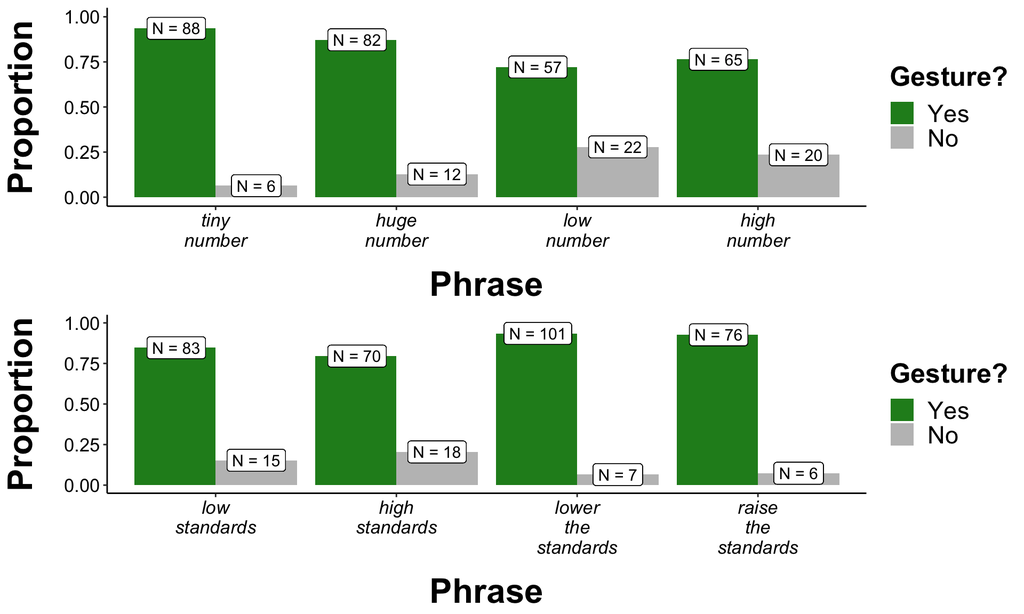

```r
# Re-order variables:
props_num$Phrase <- factor(props_num$Phrase, levels = c("tiny_number", "huge_number", "low_number", "high_number"))   # x-axis
props_num$Gesture <- factor(props_num$Gesture, levels = c("yes", "no"))    # Legend
props_stan$Phrase <- factor(props_stan$Phrase, levels = c("low_standards", "high_standards", "lower_the_standards", "raise_the_standards"))   # x-axis
props_stan$Gesture <- factor(props_stan$Gesture, levels = c("yes", "no"))    # Legend

# Make 'numbers' graph:
plot1 <-
  props_num %>%
  ggplot(aes(x = Phrase, y = Proportion, fill = factor(Gesture))) +
  geom_bar(stat = "identity", position = "dodge") +
  ylim(0, 1) +
  theme_classic() +
  xlab('Phrase') +
  ylab('Proportion') +
  theme(axis.title = bold.24.text, legend.text = element_text(size = 17), legend.title = bold.21.text) +
  theme(axis.text = black.13.text, axis.text.x = element_text(face = "italic")) +
  theme(axis.title.y = element_text(margin = margin(t = 0, r = 20, b = 0, l = 0))) +
  theme(axis.title.x = element_text(margin = margin(t = 15, r = 0, b = 0, l = 0))) +
  scale_fill_manual(values = c('forestgreen', 'grey75'), breaks = c("yes", "no"), name = "Gesture?", labels = c("Yes", "No")) +
  scale_x_discrete(labels = addline_format(c("tiny number", "huge number", "low number", "high number"))) +
  geom_label(aes(x = 0.7825, y = 0.93617021, label = "N = 88"), fill = "white", size = 4) +
  geom_label(aes(x = 1.225, y = 0.06382979, label = "N = 6"), fill = "white", size = 4) +
  geom_label(aes(x = 1.7825, y = 0.87234043, label = "N = 82"), fill = "white", size = 4) +
  geom_label(aes(x = 2.225, y = 0.12765957, label = "N = 12"), fill = "white", size = 4) +
  geom_label(aes(x = 2.7825, y = 0.72151899, label = "N = 57"), fill = "white", size = 4) +
  geom_label(aes(x = 3.225, y = 0.27848101, label = "N = 22"), fill = "white", size = 4) +
  geom_label(aes(x = 3.7825, y = 0.76470588, label = "N = 65"), fill = "white", size = 4) +
  geom_label(aes(x = 4.225, y = 0.23529412, label = "N = 20"), fill = "white", size = 4)

ggsave('gesture_cooccurrence_nums.pdf', width = 10, height = 6)

# Make 'standards' graph
plot2 <-
  props_stan %>%
  ggplot(aes(x = Phrase, y = Proportion, fill = factor(Gesture))) +
  geom_bar(stat = "identity", position = "dodge") +
  ylim(0, 1) +
  theme_classic() +
  xlab('Phrase') +
  ylab('Proportion') +
  theme(axis.title = bold.24.text, legend.text = element_text(size = 17), legend.title = bold.21.text) +
  theme(axis.text = black.13.text, axis.text.x = element_text(face = "italic")) +
  theme(axis.title.y = element_text(margin = margin(t = 0, r = 20, b = 0, l = 0))) +
  theme(axis.title.x = element_text(margin = margin(t = 15, r = 0, b = 0, l = 0))) +
  scale_fill_manual(values = c('forestgreen', 'grey75'), breaks = c("yes", "no"), name = "Gesture?", labels = c("Yes", "No")) +
  scale_x_discrete(labels = addline_format(c("low standards", "high standards", "lower the standards", "raise the standards"))) +
  geom_label(aes(x = 0.7825, y = 0.84693878, label = "N = 83"), fill = "white", size = 4) +
  geom_label(aes(x = 1.225, y = 0.15306122, label = "N = 15"), fill = "white", size = 4) +
  geom_label(aes(x = 1.7825, y = 0.79545455, label = "N = 70"), fill = "white", size = 4) +
  geom_label(aes(x = 2.225, y = 0.20454545, label = "N = 18"), fill = "white", size = 4) +
  geom_label(aes(x = 2.7825, y = 0.93518519, label = "N = 101"), fill = "white", size = 4) +
  geom_label(aes(x = 3.225, y = 0.06481481, label = "N = 7"), fill = "white", size = 4) +
  geom_label(aes(x = 3.7825, y = 0.92682927, label = "N = 76"), fill = "white", size = 4) +
  geom_label(aes(x = 4.225, y = 0.07317073, label = "N = 6"), fill = "white", size = 4)

ggsave('gesture_cooccurrence_stan.pdf', width = 10, height = 6)

grid.arrange(plot1, plot2)
```

Gesture co-occurrence was pretty high for all the phrases in the dataset, with the lowest percentage being 72%.

We predicted that speakers would be more likely to gesture when saying ‘tiny/huge number’ than when saying ‘low/high number’. Let’s see if this prediction is borne out by the data.

```r
# Restrict dataset to 'number' phrases:
full2 <- filter(full, Phrase %in% c("tiny_number", "huge_number", "low_number", "high_number"))

# Create new column for tiny and huge vs. low and high:
full2 <- mutate(full2, SizeVsHeight = ifelse(Phrase %in% c('tiny_number', 'huge_number'), 'size', 'height'))

# Check that it's worked:
set.seed(13)    # Make example reproducible
sample_n(full2, 10) %>%
  select(Phrase, SizeVsHeight)
```

```
## # A tibble: 10 x 2
##    Phrase      SizeVsHeight
##    <chr>       <chr>
##  1 low_number  height
##  2 tiny_number size
##  3 huge_number size
##  4 huge_number size
##  5 high_number height
##  6 tiny_number size
##  7 low_number  height
##  8 low_number  height
##  9 high_number height
## 10 huge_number size
```

```r
# Compare gesture co-occurrence across size and height phrases:
(xtab <- table(full2$SizeVsHeight, full2$HandsMoving))    # Raw counts
```

```
##
##           no yes
##   height  42 122
##   size    18 170
```

```r
round(prop.table(xtab, 1), 3) * 100    # Row-wise percentages
```

```
##
##            no  yes
##   height 25.6 74.4
##   size    9.6 90.4
```

```r
# Preliminaries:
full2$SizeVsHeight <- as.factor(full2$SizeVsHeight)    # Turn SizeVsHeight into a factor
full2$HandsMoving <- as.factor(full2$HandsMoving)     # Turn HandsMoving into a factor

# Input, summarise and plot logistic regression model:
summary(LR <- glm(HandsMoving ~ SizeVsHeight, data = full2, family = "binomial"))
```

```
##
## Call:
## glm(formula = HandsMoving ~ SizeVsHeight, family = "binomial",
##     data = full2)
##
## Deviance Residuals:
##     Min       1Q   Median       3Q      Max
## -2.1661   0.4486   0.4486   0.7692   0.7692
##
## Coefficients:
##                  Estimate Std. Error z value Pr(>|z|)
## (Intercept)        1.0664     0.1789   5.961 2.51e-09 ***
## SizeVsHeightsize   1.1791     0.3057   3.857 0.000115 ***
## ---
## Signif. codes:  0 '***' 0.001 '**' 0.01 '*' 0.05 '.' 0.1 ' ' 1
##
## (Dispersion parameter for binomial family taken to be 1)
##
##     Null deviance: 321.45  on 351  degrees of freedom
## Residual deviance: 305.29  on 350  degrees of freedom
##   (8 observations deleted due to missingness)
## AIC: 309.29
##
## Number of Fisher Scoring iterations: 4
```

This model supports our above interpretation of the data. However, because some speakers appeared in the dataset more than once, the independence assumption of the model is violated. To account for this, let’s run a for loop that samples the dataset with only unique speakers 1000 times.

```r
# Preliminaries:
set.seed(13)    # Make example reproducible
nsim <- 1000    # Create object containing information about number of simulations
loop_p <- numeric(length = nsim)    # Create numeric object to store p-values from simulations

# Run for loop:
for (i in 1:nsim) {
  size_loop <- sample_n(full2, size = nrow(full2))
  size_reduc <- filter(size_loop, !duplicated(SpeakerName))
  summary(LR <- glm(HandsMoving ~ SizeVsHeight, data = full2, family = "binomial"))
  loop_p[i] <- summary(LR)$coefficients[2,4]}

# Find number of p-values less than 0.05
sum(loop_p < 0.05)
```

```
## [1] 1000
```

We also predicted that speakers would be more likely to gesture when using a metaphorical verb (‘lower/raise the standard’) than when using a metaphorical adjective (‘low/high standards’). Let’s check out the descriptive stats for this.

```r
# Restrict dataset to 'standard' phrases:
full2 <- filter(full, Phrase %in% c("low_standards", "high_standards", "lower_the_standards", "raise_the_standards"))

# Create column for verb versus adjective phrases:
full2 <- mutate(full2, VerbVsAdj = ifelse(Phrase %in% c("high_standards", "low_standards"), "Adj", "Verb"))

# Check that it's worked:
set.seed(13)    # Make example reproducible
sample_n(full2, 10) %>%
  select(Phrase, VerbVsAdj)
```

```
## # A tibble: 10 x 2
##    Phrase              VerbVsAdj
##    <chr>               <chr>
##  1 lower_the_standards Verb
##  2 low_standards       Adj
##  3 high_standards      Adj
##  4 low_standards       Adj
##  5 raise_the_standards Verb
##  6 low_standards       Adj
##  7 lower_the_standards Verb
##  8 lower_the_standards Verb
##  9 raise_the_standards Verb
## 10 low_standards       Adj
```

```r
# Compare gesture co-occurrence across verb and adjective phrases:
(xtab <- table(full2$VerbVsAdj, full2$HandsMoving))    # Raw counts
```

```
##
##         no yes
##   Adj   33 153
##   Verb  13 177
```

```r
round(prop.table(xtab, 1), 3) * 100    # Row-wise percentages
```

```
##
##          no  yes
##   Adj  17.7 82.3
##   Verb  6.8 93.2
```

```r
# Turn columns into factors:
full2$VerbVsAdj <- as.factor(full2$VerbVsAdj)
full2$HandsMoving <- as.factor(full2$HandsMoving)

# Input, summarise and plot logistic regression model:
summary(log_reg <- glm(HandsMoving ~ VerbVsAdj, data = full2, family = "binomial"))
```

```
##
## Call:
## glm(formula = HandsMoving ~ VerbVsAdj, family = "binomial", data = full2)
##
## Deviance Residuals:
##     Min       1Q   Median       3Q      Max
## -2.3161   0.3765   0.3765   0.6250   0.6250
##
## Coefficients:
##               Estimate Std. Error z value Pr(>|z|)
## (Intercept)     1.5339     0.1919   7.992 1.33e-15 ***
## VerbVsAdjVerb   1.0773     0.3456   3.117  0.00182 **
## ---
## Signif. codes:  0 '***' 0.001 '**' 0.01 '*' 0.05 '.' 0.1 ' ' 1
##
## (Dispersion parameter for binomial family taken to be 1)
##
##     Null deviance: 279.41  on 375  degrees of freedom
## Residual deviance: 268.72  on 374  degrees of freedom
##   (1 observation deleted due to missingness)
## AIC: 272.72
##
## Number of Fisher Scoring iterations: 5
```

```r
set.seed(13)    # Make example reproducible
nsim <- 1000    # Create object containing information about number of simulations
loop_p <- numeric(length = nsim)    # Create numeric object to store p-values from simulations

for (i in 1:nsim) {
  df_loop <- sample_n(full2, size = nrow(full2))
  df_reduc <- filter(df_loop, !duplicated(SpeakerName))
  summary(log_reg <- glm(HandsMoving ~ VerbVsAdj + Phrase, data = df_reduc, family = "binomial"))
  loop_p[i] <- summary(log_reg)$coefficients[2,4]}

sum(loop_p < 0.05)    # Find number of p-values less than 0.05
```

```
## [1] 1000
```

All 1000 samples returned a statistically significant result.

# 5 Articulatory plurality

We now look at articulatory plurality. We predict that speakers will be more likely to use two hands to gesture when using plural nouns (‘numbers’/‘standards’), and to use one hand to gesture when using singular nouns (‘number’/‘standard’).

```r
# Filter dataset to only those videos where both the speakers' hands are free to gesture:
full2 <- filter(full, HandsFree %in% c('both', 'both/object', 'both/oneobject'))    # HandsFree == 'both'

# Add column comparing one-handed versus both-handed gestures:
full2 <- mutate(full2, OneVsBoth = ifelse(WhichHand %in% c("L", "R"), "one", "both"))

# Check that it's worked by randomly sampling dataset:
set.seed(13)    # Make example reproducible
sample_n(full2, 10) %>%
  select(WhichHand, OneVsBoth)
```

```
## # A tibble: 10 x 2
##    WhichHand OneVsBoth
##    <chr>     <chr>
##  1 L         one
##  2 both      both
##  3 both      both
##  4 both      both
##  5 L         one
##  6 R         one
##  7 both      both
##  8 both      both
##  9 both      both
## 10 both      both
```

```r
# Look at raw counts and row-wise percentages
(xtab <- table(full2$Plural, full2$OneVsBoth))    # Raw counts
```

```
##
##       both one
##   no   147  53
##   yes  104  35
```

```r
round(prop.table(xtab, 1), 3) * 100    # Row-wise percentages
```

```
##
##       both  one
##   no  73.5 26.5
##   yes 74.8 25.2
```

Plot this (Figure 4):

```r
# Preliminary work to make graph showing MovementHorizontal across Phrase:
(xtab <- table(full2$Plural, full2$OneVsBoth))   # Tabulate raw data
```

```
##
##       both one
##   no   147  53
##   yes  104  35
```

```r
prop.table <- prop.table(xtab, 1)    # Tabulate proportions
xtab <- as.data.frame(prop.table)   # Turn table into dataframe
as.numeric(xtab$Freq)   # Turn Frequency into numeric variable
```

```
## [1] 0.7350000 0.7482014 0.2650000 0.2517986
```

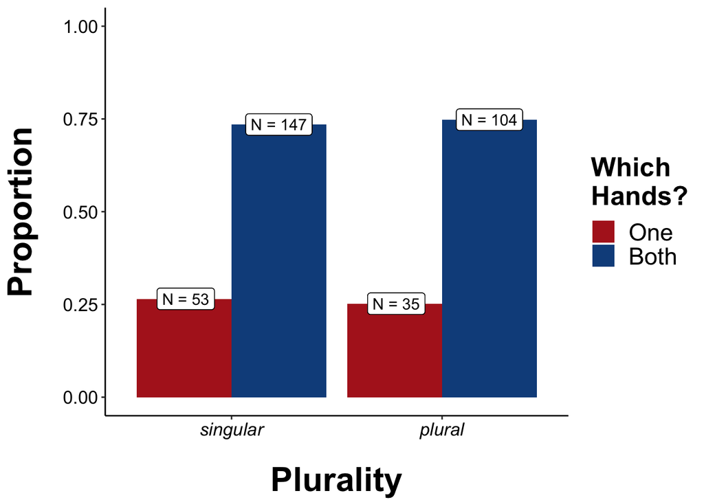

```r
xtab$Var2 <- factor(xtab$Var2, levels = c("one", "both"))   # Re-order x-axis labels

# Make graph:
xtab %>%
  ggplot(aes(x = xtab$Var1, y = Freq, fill = xtab$Var2)) +
  geom_bar(stat = "identity", position = "dodge") +
  ylim(0, 1) +
  theme_classic() +
  xlab('Plurality') +
  ylab('Proportion') +
  theme(axis.title = bold.24.text, legend.text = element_text(size = 17), legend.title = bold.21.text) +
  theme(axis.text = black.13.text, axis.text.x = element_text(face = "italic")) +
  theme(axis.title.y = element_text(margin = margin(t = 0, r = 20, b = 0, l = 0))) +
  theme(axis.title.x = element_text(margin = margin(t = 20, r = 0, b = 0, l = 0))) +
  scale_fill_manual(values = c('firebrick', 'dodgerblue4'), name = addline_format("Which Hands?"), labels = c("One", "Both")) +
  scale_x_discrete(labels = c('singular', 'plural')) +
  geom_label(aes(x = 0.7825, y = 0.265, label = "N = 53"), fill = "white", size = 4) +
  geom_label(aes(x = 1.225, y = 0.735, label = "N = 147"), fill = "white", size = 4) +
  geom_label(aes(x = 1.7825, y = 0.252, label = "N = 35"), fill = "white", size = 4) +
  geom_label(aes(x = 2.225, y = 0.748, label = "N = 104"), fill = "white", size = 4)
```

```r
ggsave("articulatory_plurality.pdf", width = 6, height = 4.5)
```

It looks like there’s hardly any difference between the singular and plural variants, but there is a very slight trend in the direction of our hypothesis. Let’s check this with logistic regression.

```r
# Create column for larger quantities versus smaller quantities:
full2 <- mutate(full2, SmallVsLarge = ifelse(Phrase %in% c('tiny_number', 'low_number', 'low_standards', 'lower_the_standards'), 'small', 'large'))

full2$Plural <- as.factor(full2$Plural)     # Turn NounPlural into a factor
full2$OneVsBoth <- factor(full2$OneVsBoth, levels = c("one", "both"))   # Turn MovementVertical into a factor and re-order levels

# Input, summarise and plot logistic regression model:
summary(LR <- glm(OneVsBoth ~ Plural + SmallVsLarge, data = full2, family = "binomial"))
```

```
##
## Call:
## glm(formula = OneVsBoth ~ Plural + SmallVsLarge, family = "binomial",
##     data = full2)
##
## Deviance Residuals:
##     Min       1Q   Median       3Q      Max
## -1.6840  -1.6075   0.7678   0.7777   0.8015
##
## Coefficients:
##                   Estimate Std. Error z value Pr(>|z|)
## (Intercept)        1.07057    0.20442   5.237 1.63e-07 ***
## Pluralyes          0.07001    0.25278   0.277    0.782
## SmallVsLargesmall -0.09969    0.24801  -0.402    0.688
## ---
## Signif. codes:  0 '***' 0.001 '**' 0.01 '*' 0.05 '.' 0.1 ' ' 1
##
## (Dispersion parameter for binomial family taken to be 1)
##
##     Null deviance: 388.24  on 338  degrees of freedom
## Residual deviance: 388.00  on 336  degrees of freedom
##   (26 observations deleted due to missingness)
## AIC: 394
##
## Number of Fisher Scoring iterations: 4
```

This model reveals no significant effect of articulatory plurality.

It could be possible, however, that the phrases ‘tiny number’, ‘low number’, ‘low standards’ and ‘lower the standards’ are more likely to be described with a singular noun, and that the phrases ‘huge number’, ‘high number’, ‘high standards’ and ‘raise the standards’ are more likely to be described with a plural noun, which would raise a collinearity issue. Check this with Variance Inflation Factors:

```r
vif(LR)   # Lower than 3 == no collinearity
```

```
##       Plural SmallVsLarge
##     1.000126     1.000126
```

Doesn’t look like there was an issue.

# 6 Orders of magnitude

## 6.1 Orders of magnitude: tiny/huge

Let’s now look at orders of magnitude by creating an additional column in the dataset that takes the logarithmic value in powers of ten of the QuantityValue column:

```r
size2 <- filter(size, QuantityType == 'number')   # Only look at 'number' values
size2$QuantityValue <- as.numeric(size2$QuantityValue)    # Turn QuantityValue into numeric vector
size2 <- mutate(size2, Magnitude = log10(QuantityValue))    # Create column taking the log10 of QuantityValue
size2$Magnitude <- as.numeric(substr(size2$Magnitude, 1,2))    # Print only first two digits
select(size2, QuantityValue, Magnitude)    # Look at QuantityValue and Magnitude columns
```

```
## # A tibble: 30 x 2
##    QuantityValue Magnitude
##            <dbl>     <dbl>
##  1             7         0
##  2            50         1
##  3         10000         4
##  4       7000000         6
##  5         22004         4
##  6         10000         4
##  7            17         1
##  8       1000000         6
##  9       1000000         6
## 10      30000000         7
## # ... with 20 more rows
```

Look at Magnitude across Phrase:

```r
(xtab <- table(size2$Phrase, size2$Magnitude))    # Raw figures
```

```
##
##               0 1 2 3 4 6 7 9 10 13
##   tiny_number 1 2 3 1 2 2 0 2  0  0
##   huge_number 1 4 0 1 3 3 3 0  1  1
```

```r
round(prop.table(xtab, 1), 3) * 100   # Row-wise percentages
```

```
##
##                  0    1    2    3    4    6    7    9   10   13
##   tiny_number  7.7 15.4 23.1  7.7 15.4 15.4  0.0 15.4  0.0  0.0
##   huge_number  5.9 23.5  0.0  5.9 17.6 17.6 17.6  0.0  5.9  5.9
```

Look at HandConfig across Phrase:

```r
(xtab <- table(size2$HandConfig, size2$Magnitude))    # Raw figures
```

```
##
##          0 1 2 3 4 6 7 9 10 13
##   closed 0 0 2 0 1 0 0 1  0  0
##   open   1 5 0 1 3 5 2 1  1  1
```

```r
round(prop.table(xtab, 1), 3) * 100   # Row-wise percentages
```

```
##
##           0  1  2  3  4  6  7  9 10 13
##   closed  0  0 50  0 25  0  0 25  0  0
##   open    5 25  0  5 15 25 10  5  5  5
```

This seems to show that whether a speaker describes a number as ‘tiny’ or ‘huge’ is dependent on relative rather than absolute quantity. Likewise, whether a speaker uses a closed or open hand shape also seems to depend on relative rather than absolute quantity. Not much can be said about vertical movement because of the low numbers.

Let’s look at gesture co-occurrence as a function of magnitude:

```r
(xtab <- table(size2$HandsMoving, size2$Magnitude))    # Raw figures
```

```
##
##       0 1 2 3 4 6 7 9 10 13
##   no  1 1 1 1 1 0 1 0  0  0
##   yes 1 5 2 1 4 5 2 2  1  1
```

```r
round(prop.table(xtab, 1), 3) * 100   # Row-wise percentages
```

```
##
##          0    1    2    3    4    6    7    9   10   13
##   no  16.7 16.7 16.7 16.7 16.7  0.0 16.7  0.0  0.0  0.0
##   yes  4.2 20.8  8.3  4.2 16.7 20.8  8.3  8.3  4.2  4.2
```

Absolute magnitude does not seem to predict gesture co-occurrence.

## 6.2 Orders of magnitude: low/high

Let’s now look at orders of magnitude by creating an additional column in the dataset that takes the logarithmic value in powers of ten of the QuantityValue column:

```r
height2 <- filter(height, QuantityType == 'number')   # Only look at 'number' values
height2$QuantityValue <- as.numeric(height2$QuantityValue)    # Turn QuantityValue into numeric vector
height2 <- mutate(height2, Magnitude = log10(QuantityValue))    # Create column taking the log10 of QuantityValue
height2$Magnitude <- as.numeric(substr(height2$Magnitude, 1,2))    # Print only first two digits
select(height2, QuantityValue, Magnitude)   # Look at QuantityValue and Magnitude columns
```

```
## # A tibble: 50 x 2
##    QuantityValue Magnitude
##            <dbl>     <dbl>
##  1       5.00e 1         1
##  2       1.90e 6         6
##  3       3.70e 1         1
##  4       1.00e 6         6
##  5       1.00e 3         3
##  6       2.50e 0         0
##  7       3.58e 5         5
##  8       1.00e 9         9
##  9       6.00e 0         0
## 10       1.00e12        12
## # ... with 40 more rows
```

Look at Magnitude across Phrase:

```r
(xtab <- table(height2$Phrase, height2$Magnitude))    # Raw figures
```

```
##
##                0  1  2  3  4  5  6  7  8  9 10 11 12
##   low_number   3 12  2  1  3  1  1  1  0  1  1  0  1
##   high_number  1  7  1  2  0  2  3  2  1  2  0  2  0
```

```r
round(prop.table(xtab, 1), 3) * 100   # Row-wise percentages
```

```
##
##                  0    1    2    3    4    5    6    7    8    9   10   11
##   low_number  11.1 44.4  7.4  3.7 11.1  3.7  3.7  3.7  0.0  3.7  3.7  0.0
##   high_number  4.3 30.4  4.3  8.7  0.0  8.7 13.0  8.7  4.3  8.7  0.0  8.7
##
##                 12
##   low_number   3.7
##   high_number  0.0
```

Look at HandConfig across Magnitude:

```r
(xtab <- table(height2$HandConfig, height2$Magnitude))    # Raw figures
```

```
##
##           0  1  2  3  4  5  6  7  8  9 10 11 12
##   closed  2  3  1  1  0  0  1  1  1  0  0  1  0
##   open    2 11  0  2  0  1  2  1  0  2  1  0  1
```

```r
round(prop.table(xtab, 1), 3) * 100   # Row-wise percentages
```

```
##
##             0    1    2    3    4    5    6    7    8    9   10   11   12
##   closed 18.2 27.3  9.1  9.1  0.0  0.0  9.1  9.1  9.1  0.0  0.0  9.1  0.0
##   open    8.7 47.8  0.0  8.7  0.0  4.3  8.7  4.3  0.0  8.7  4.3  0.0  4.3
```

Look at Magnitude across MovementVertical:

```r
(xtab <- table(height2$MovementVertical, height2$Magnitude))    # Raw figures
```

```
##
##        0 1 2 3 4 5 6 7 8 9 10 11 12
##   down 2 7 0 1 0 0 2 0 1 1  0  1  1
##   up   0 2 0 1 0 0 0 1 0 0  0  0  0
```

```r
round(prop.table(xtab, 1), 3) * 100   # Row-wise percentages
```

```
##
##           0    1    2    3    4    5    6    7    8    9   10   11   12
##   down 12.5 43.8  0.0  6.2  0.0  0.0 12.5  0.0  6.2  6.2  0.0  6.2  6.2
##   up    0.0 50.0  0.0 25.0  0.0  0.0  0.0 25.0  0.0  0.0  0.0  0.0  0.0
```

This seems to show that whether a speaker describes a number as ‘low’ or ‘high’ is dependent on relative rather than absolute quantity. Likewise, whether a speaker uses a closed or open hand shape also seems to depend on relative rather than absolute quantity. Not much can be said about vertical movement because of the low numbers.

Let’s look at gesture co-occurrence as a function of magnitude:

```r
(xtab <- table(height2$HandsMoving, height2$Magnitude))    # Raw figures
```

```
##
##        0  1  2  3  4  5  6  7  8  9 10 11 12
##   no   1  6  2  0  3  2  2  1  0  1  0  1  0
##   yes  3 13  1  3  0  1  2  2  1  2  1  1  1
```

```r
round(prop.table(xtab, 1), 3) * 100   # Row-wise percentages
```

```
##
##          0    1    2    3    4    5    6    7    8    9   10   11   12
##   no   5.3 31.6 10.5  0.0 15.8 10.5 10.5  5.3  0.0  5.3  0.0  5.3  0.0
##   yes  9.7 41.9  3.2  9.7  0.0  3.2  6.5  6.5  3.2  6.5  3.2  3.2  3.2
```

There doesn’t seem to be any clear pattern here.